# Context & Objectives

#### Adam Optimizer & Dropout

##### Model Architecture

```python
# clears the current Keras session, resetting all layers and models previously created, freeing up memory and resources.
tf.keras.backend.clear_session()
```

```python
# setting random seeds to ensure consistent and reproducible results
np.random.seed(2)
random.seed(2)
tf.random.set_seed(2)
```

```python
#Initializing the neural network
model_2 = Sequential()
model_2.add(Dense(11, activation='tanh', input_dim=X_train.shape[1]))
model_2.add(Dropout(0.2)) # Adding dropout
model_2.add(Dense(3, activation='relu')) # Adding a hidden layer
model_2.add(Dropout(0.1)) # Adding dropout
model_2.add(Dense(2, activation='relu')) # Adding a hidden layer
model_2.add(Dense(1, activation='sigmoid'))
```

- We've set the input layer to 11 neurons which corresponds to the number of features in our training data.
- After much experimentation, we've chosen to use Tanh in the activation layer which we found to help with unbalanced data, and ReLU in our hidden layers particularly in deeper layers to help avoid vanishing gradient occasionally seen with tanh.
- We've experimented with a diverse number of parameters, and found that adding 2 dropouts at 0.2 and 0.1 respectively and 2 hidden layers with a relatively low number of neurons seem to lead to better performance on the overall.
- The output layer has a single neuron with a sigmoid activation function often preferred for classification problems.

```python
# outputting the model summary
model_2.summary()
```

```
Model: "sequential"
_________________________________________________________________
 Layer (type)                Output Shape              Param #
=================================================================
 dense (Dense)               (None, 11)                132

 dropout (Dropout)           (None, 11)                0

 dense_1 (Dense)             (None, 3)                 36

 dropout_1 (Dropout)         (None, 3)                 0

 dense_2 (Dense)             (None, 2)                 8

 dense_3 (Dense)             (None, 1)                 3

=================================================================
Total params: 179 (716.00 Byte)
Trainable params: 179 (716.00 Byte)
Non-trainable params: 0 (0.00 Byte)
_________________________________________________________________
```

##### Model Compiling

```python
from tensorflow.keras.metrics import Recall

# compiling the model
optimizer = tf.keras.optimizers.Adam()    # defining Adam as the optimizer to be used
model_2.compile(loss='binary_crossentropy', optimizer=optimizer, metrics=[Recall()]) # defining binary crossentropy as the loss function
```

```python
start = time.time()

# fitting the model
history_2 = model_2.fit(
    X_train,
    y_train,
    validation_data = (X_val, y_val),
    batch_size = batch_size,
    epochs = epochs,
    verbose = 1,
)
end = time.time()

print(f"Training time: {end - start}")
```

```
Training time: 3.1512093544006348
```

We're seeing stabilization in the learning process possibly indicating a less likelihood of tanh introducing vanishing gradients.

##### Model Evaluation

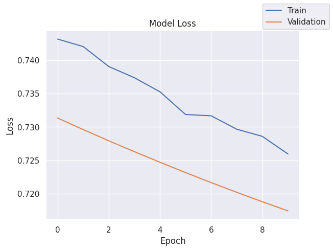

```python
plot(history_2, 'loss')
```

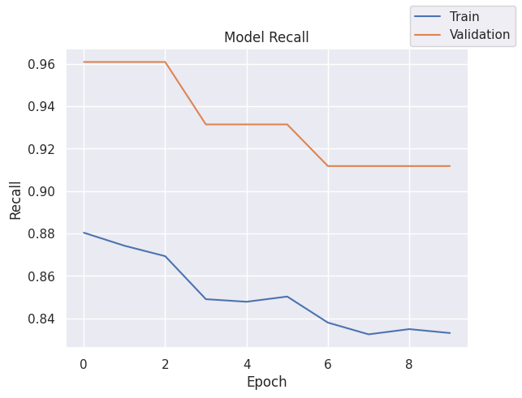

```python
plot(history_2, 'recall')
```

```python
#Predicting the results using best as a threshold
y_train_pred_ad = model_2.predict(X_train)
y_train_pred_ad = (y_train_pred_ad > 0.5)
y_train_pred_ad
```

```
array([[ True],
       [ True],
       [ True],
       ...,
       [ True],
       [ True],
       [ True]])
```

```python
#Predicting the results using best as a threshold
y_val_pred_ad = model_2.predict(X_val)
y_val_pred_ad = (y_val_pred_ad > 0.5)
y_val_pred_ad
```

```
array([[ True],
       [ True],
       [False],
       ...,
       [ True],
       [ True],
       [ True]])
```

```python
# classification report
cr_ad_train = classification_report(y_train, y_train_pred_ad)
print(cr_ad_train)
```

```
              precision    recall  f1-score   support

           0       0.86      0.20      0.32      6370
           1       0.22      0.88      0.35      1630

    accuracy                           0.34      8000
   macro avg       0.54      0.54      0.34      8000
weighted avg       0.73      0.34      0.33      8000
```

```python
# classification report
cr_ad_val = classification_report(y_val, y_val_pred_ad)
print(cr_ad_val)
```

```
              precision    recall  f1-score   support

           0       0.92      0.25      0.39       398
           1       0.24      0.91      0.38       102

    accuracy                           0.38       500
   macro avg       0.58      0.58      0.38       500
weighted avg       0.78      0.38      0.39       500
```

```
None
```

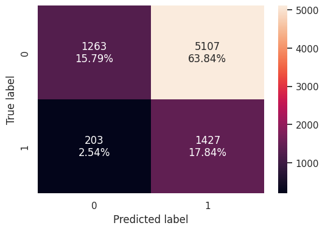

```python
cm_ad_train = make_confusion_matrix(y_train, y_train_pred_ad)
print(cm_ad_train)
```

```
None
```

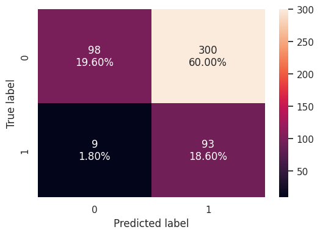

```python
cm_ad_val = make_confusion_matrix(y_val, y_val_pred_ad)
print(cm_ad_val)
```

Overall, the model's performance in terms of recall is better on the validation set compared to the training set, particularly for Class 0. This could indicate that the model is generalizing well to unseen data. However, further optimization may still be beneficial to improve the recall for both classes on both sets.

```python
model_name = "NN with Adam & Dropout"

train_metric_df.loc[model_name] = recall_score(y_train, y_train_pred_ad)
valid_metric_df.loc[model_name] = recall_score(y_val, y_val_pred_ad)
```

#### SMOTE & SGD

##### Model Architecture

```python
from imblearn.over_sampling import SMOTE

sm = SMOTE(random_state=42)
X_train_smote, y_train_smote = sm.fit_resample(X_train, y_train)

print('After UpSampling, the shape of train_X: {}'.format(X_train_smote.shape))
print('After UpSampling, the shape of train_y: {} \n'.format(y_train_smote.shape))
```

```
After UpSampling, the shape of train_X: (12740, 11)
After UpSampling, the shape of train_y: (12740,)
```

```python
# clears the current Keras session, resetting all layers and models previously created, freeing up memory and resources.
tf.keras.backend.clear_session()
```

```python
# setting random seeds to ensure consistent and reproducible results
np.random.seed(2)
random.seed(2)
tf.random.set_seed(2)
```

```python
#Initializing the neural network
model_4 = Sequential()
model_4.add(Dense(11, activation='relu', input_dim=X_train_smote.shape[1]))
model_4.add(Dense(30, activation='tanh'))
model_4.add(Dense(16, activation='relu'))
model_4.add(Dense(1, activation='sigmoid'))
```

- We've set the input layer to 11 neurons which corresponds to the number of features in our training data.
- After much experimentation, we've chosen to use Tanh in one of the hidden layers which we found to be helpful with unbalanced data, and ReLU in our activation and hidden layers particularly in deeper layers to help avoid vanishing gradient occasionally seen with tanh.
- We've experimented with a diverse number of parameters, and found that adding 2 hidden layers set at 30 and 16 respectively seem to output best results for our key metric.
- The output layer has a single neuron with a sigmoid activation function often preferred for classification problems.

```python
# outputting the model summary
model_4.summary()
```

```
Model: "sequential"
_________________________________________________________________
 Layer (type)                Output Shape              Param #
=================================================================
 dense (Dense)               (None, 11)                132

 dense_1 (Dense)             (None, 30)                360

 dense_2 (Dense)             (None, 16)                496

 dense_3 (Dense)             (None, 1)                 17

=================================================================
Total params: 1005 (3.93 KB)
Trainable params: 1005 (3.93 KB)
Non-trainable params: 0 (0.00 Byte)
_________________________________________________________________
```

##### Model Compilation

```python
# compiling the model
optimizer = tf.keras.optimizers.SGD()    # defining SGD as the optimizer to be used
model_4.compile(loss='binary_crossentropy', optimizer=optimizer, metrics=[Recall()]) # defining binary crossentropy as the loss function
```

- Chosing to explore SGD optimizer in conjuction with SMOTE
- Persisting with binary_crossentropy for consistency and replicability

```python
start = time.time()

# fitting the model
history_4 = model_4.fit(
    X_train_smote,
    y_train_smote,
    validation_data = (X_val, y_val),
    batch_size = batch_size,
    epochs = epochs,
    verbose = 1,
)
end = time.time()

print(f"Training time: {end - start}")
```

```
Training time: 2.2500617504119873
```

##### Model Evaluation

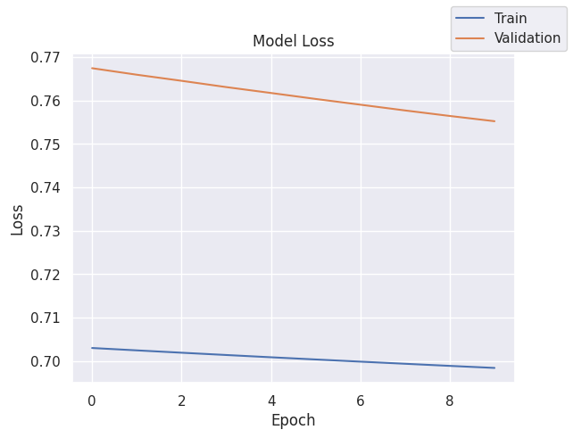

```python
plot(history_4, 'loss')
```

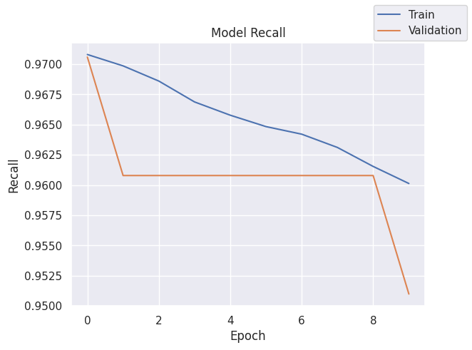

```python
plot(history_4, 'recall')
```

```python
#Predicting the results using best as a threshold
y_train_pred_sgds = model_4.predict(X_train_smote)
y_train_pred_sgds = (y_train_pred_sgds > 0.5)
y_train_pred_sgds
```

```
array([[False],
       [ True],
       [ True],
       ...,
       [ True],
       [ True],
       [ True]])
```

```python
#Predicting the results using best as a threshold
y_val_pred_sgds = model_4.predict(X_val)
y_val_pred_sgds = (y_val_pred_sgds > 0.5)
np.set_printoptions(threshold=10) # limit the threshold of the output
y_val_pred_sgds
```

```
array([[ True],
       [ True],
       [ True],
       ...,
       [ True],
       [ True],
       [ True]])
```

```python
# classification report
cr_sgds_smote_train = classification_report(y_train_smote, y_train_pred_sgds)
print(cr_sgds_smote_train)
```

```
              precision    recall  f1-score   support

           0       0.35      0.02      0.04      6370
           1       0.50      0.96      0.65      6370

    accuracy                           0.49     12740
   macro avg       0.42      0.49      0.35     12740
weighted avg       0.42      0.49      0.35     12740
```

- Recall: For class 0, the recall is very low at 0.02, indicating that the model is not effectively capturing instances of class 0. However, for class 1, the recall is high at 0.96, suggesting that the model performs well in identifying instances of class 1.
- Accuracy: The overall accuracy of the model on the training set is 0.49, indicating that approximately half of the predictions are correct.
- Precision: The precision for class 0 is 0.35, indicating that when the model predicts class 0, it is correct only 35% of the time. For class 1, the precision is higher at 0.50, indicating that the model's positive predictions for class 1 are more reliable.
- F1-Score: The F1-score, which balances precision and recall, is low for both classes, with a weighted average of 0.35.

```python
# classification report
cr_sgds_smote_val = classification_report(y_val, y_val_pred_sgds)
print(cr_sgds_smote_val)
```

```
              precision    recall  f1-score   support

           0       0.55      0.02      0.03       398
           1       0.20      0.95      0.33       102

    accuracy                           0.21       500
   macro avg       0.37      0.48      0.18       500
weighted avg       0.47      0.21      0.09       500
```

- Recall: Similar to the training set, the recall for class 0 in the validation set is very low at 0.02, while the recall for class 1 is high at 0.95.
- Accuracy: The overall accuracy of the model on the validation set is 0.21, indicating that the model's performance is poor in generalizing to unseen data.
- Precision: The precision for class 0 is 0.55, indicating that the model's positive predictions for class 0 are correct 55% of the time. However, for class 1, the precision is low at 0.20.
- F1-Score: The F1-score is low for both classes in the validation set, with a weighted average of 0.09.

```
None
```

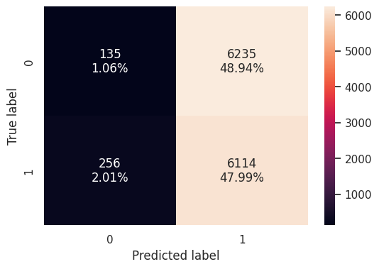

```python
cm_sgds_smote_train = make_confusion_matrix(y_train_smote, y_train_pred_sgds)
print(cm_sgds_smote_train)
```

```
None
```

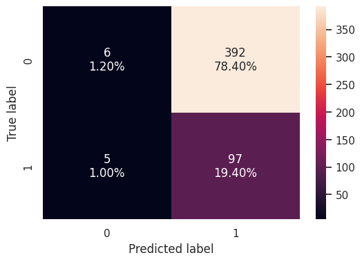

```python
cm_sgds_smote_val = make_confusion_matrix(y_val, y_val_pred_sgds)
print(cm_sgds_smote_val)
```

Overall, while the model performs well in identifying instances of class 1, its performance on class 0 is severely lacking, leading to poor overall performance metrics on the validation set. This suggests that the model may be overfitting to class 1 or struggling to generalize to instances of class 0. Further optimization and model tuning may be necessary to improve the model's performance, particularly in capturing instances of class 0.

```python
model_name = "NN with SMOTE & SGD"

train_metric_df.loc[model_name] = recall_score(y_train_smote, y_train_pred_sgds)
valid_metric_df.loc[model_name] = recall_score(y_val, y_val_pred_sgds)
```

#### SMOTE & Adam Optimizer

##### Model Architecture

```python
# clears the current Keras session, resetting all layers and models previously created, freeing up memory and resources.
tf.keras.backend.clear_session()
```

```python
# setting random seeds to ensure consistent and reproducible results
np.random.seed(2)
random.seed(2)
tf.random.set_seed(2)
```

```python
#Initializing the neural network
model_5 = Sequential()
model_5.add(Dense(11, activation='tanh', input_dim=X_train_smote.shape[1]))
model_5.add(Dense(7, activation='relu'))
model_5.add(Dense(4, activation='relu'))
model_5.add(Dense(1, activation='sigmoid'))
```

- Again, we've set the input layer to 11 neurons which corresponds to the number of features in our training data.
- After much experimentation, we've chosen to use Tanh as the activation layer which we found to be helpful with unbalanced data, and ReLU in our hidden layers particularly in deeper layers to help avoid vanishing gradient occasionally seen with tanh.
- We've experimented with a diverse number of parameters, and found that adding 2 hidden layers set a low number of neurons 7 and 4 respectively resulted in the best outcome for our model.
- The output layer has a single neuron with a sigmoid activation function often preferred for classification problems.

```python
# outputting the model summary
model_5.summary()
```

```
Model: "sequential"
_________________________________________________________________
 Layer (type)                Output Shape              Param #
=================================================================
 dense (Dense)               (None, 11)                132

 dense_1 (Dense)             (None, 7)                 84

 dense_2 (Dense)             (None, 4)                 32

 dense_3 (Dense)             (None, 1)                 5

=================================================================
Total params: 253 (1012.00 Byte)
Trainable params: 253 (1012.00 Byte)
Non-trainable params: 0 (0.00 Byte)
_________________________________________________________________
```

##### Model Compilation

```python
# compiling the model
optimizer = tf.keras.optimizers.Adam()    # defining Adam as the optimizer to be used
model_5.compile(loss='binary_crossentropy', optimizer=optimizer, metrics=[Recall()]) # defining binary crossentropy as the loss function
```

- We've opted to experiment with Adam optimizer alongside SMOTE for unbalanced data
- Continuing to user binary crossentropy as the loss function for consistency and reproducibility across models

```python
start = time.time()

# fitting the model
history_5 = model_5.fit(
    X_train_smote,
    y_train_smote,
    validation_data = (X_val, y_val),
    batch_size = batch_size,
    epochs = epochs,
    verbose = 1,
)
end = time.time()

print(f"Training time: {end - start}")
```

```
Training time: 3.0622384548187256
```

##### Model Evaluation

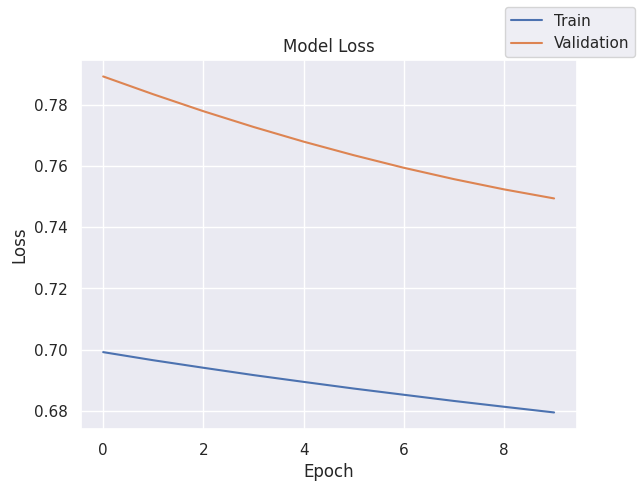

```python
plot(history_5, 'loss')
```

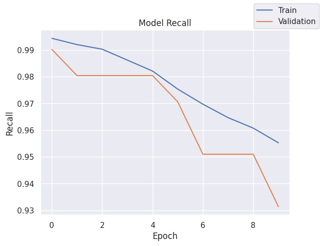

```python
plot(history_5, 'recall')
```

```python
#Predicting the results using best as a threshold
y_train_pred_as = model_5.predict(X_train_smote)
y_train_pred_as = (y_train_pred_as > 0.5)
y_train_pred_as
```

```
array([[ True],
       [ True],
       [ True],
       ...,
       [ True],
       [ True],
       [ True]])
```

```python
#Predicting the results using best as a threshold
y_val_pred_as = model_5.predict(X_val)
y_val_pred_as = (y_val_pred_as > 0.5)
np.set_printoptions(threshold=10) # limit the threshold of the output
y_val_pred_as
```

```
array([[ True],
       [ True],
       [ True],
       ...,
       [ True],
       [ True],
       [ True]])
```

```python
# classification report
cr_as_train = classification_report(y_train_smote, y_train_pred_as)
print(cr_as_train)
```

```
              precision    recall  f1-score   support

           0       0.72      0.13      0.22      6370
           1       0.52      0.95      0.67      6370

    accuracy                           0.54     12740
   macro avg       0.62      0.54      0.44     12740
weighted avg       0.62      0.54      0.44     12740
```

```python
# classification report
cr_as_val = classification_report(y_val, y_val_pred_as)
print(cr_as_val)
```

```
              precision    recall  f1-score   support

           0       0.88      0.13      0.22       398
           1       0.21      0.93      0.35       102

    accuracy                           0.29       500
   macro avg       0.55      0.53      0.29       500
weighted avg       0.74      0.29      0.25       500
```

- In the validation set, the overall accuracy drops to 29%. Similar to the training set, the precision for class 1 is relatively low at 21%, indicating that the model tends to misclassify some instances as class 1.
- However, the recall for class 1 remains high at 93%, suggesting that the model is effective at identifying instances of class 1. Unfortunately, the recall for class 0 remains low at 13%, indicating a consistent struggle to correctly identify instances of class 0.
- In validation set, accuracy goes down to 29% indicating an accuracy problem when generalizing against unseen data.

```
None
```

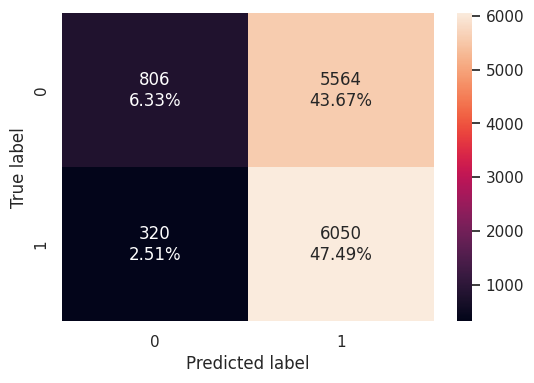

```python
cm_as_train = make_confusion_matrix(y_train_smote, y_train_pred_as)
print(cm_as_train)
```

```
None
```

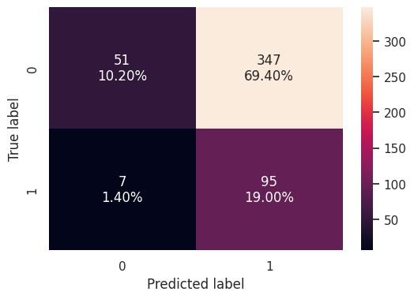

```python
cm_as_val = make_confusion_matrix(y_val, y_val_pred_as)
print(cm_as_val)
```

In summary, while the model performs well in identifying instances of class 1, it faces challenges in correctly identifying instances of class 0. This imbalance in performance between the two classes may require further investigation and potential model refinement to improve overall performance.

```python
model_name = "NN with SMOTE & ADAM"

train_metric_df.loc[model_name] = recall_score(y_train_smote, y_train_pred_as)
valid_metric_df.loc[model_name] = recall_score(y_val, y_val_pred_as)
```

#### SMOTE, Adam & Dropout

##### Model Architecture

```python
# clears the current Keras session, resetting all layers and models previously created, freeing up memory and resources.
tf.keras.backend.clear_session()
```

```python
# setting random seeds to ensure consistent and reproducible results
np.random.seed(2)
random.seed(2)
tf.random.set_seed(2)
```

```python
#Initializing the neural network
model_6 = Sequential()
model_6.add(Dense(11, activation='relu', input_dim=X_train_smote.shape[1]))
model_6.add(Dense(5, activation='tanh')) # Adding a hidden layer
model_6.add(Dropout(0.1)) # Adding dropout
model_6.add(Dense(4, activation='relu')) # Adding a hidden layer
model_6.add(Dense(1, activation='sigmoid'))
```

```python
# outputting the model summary
model_6.summary()
```

```
Model: "sequential"
_________________________________________________________________
 Layer (type)                Output Shape              Param #
=================================================================
 dense (Dense)               (None, 11)                132

 dense_1 (Dense)             (None, 5)                 60

 dropout (Dropout)           (None, 5)                 0

 dense_2 (Dense)             (None, 4)                 24

 dense_3 (Dense)             (None, 1)                 5

=================================================================
Total params: 221 (884.00 Byte)
Trainable params: 221 (884.00 Byte)
Non-trainable params: 0 (0.00 Byte)
_________________________________________________________________
```

##### Model Compilation

```python
# compiling the model
optimizer = tf.keras.optimizers.Adam()    # defining Adam as the optimizer to be used
model_6.compile(loss='binary_crossentropy', optimizer=optimizer, metrics=[Recall()]) # defining binary crossentropy as the loss function
```

```python
start = time.time()

# fitting the model
history_6 = model_6.fit(
    X_train_smote,
    y_train_smote,
    validation_data = (X_val, y_val),
    batch_size = batch_size,
    epochs = epochs,
    verbose = 1,
)
end = time.time()

print(f"Training time: {end - start}")
```

```
Training time: 3.1407783031463623
```

##### Model Evaluation

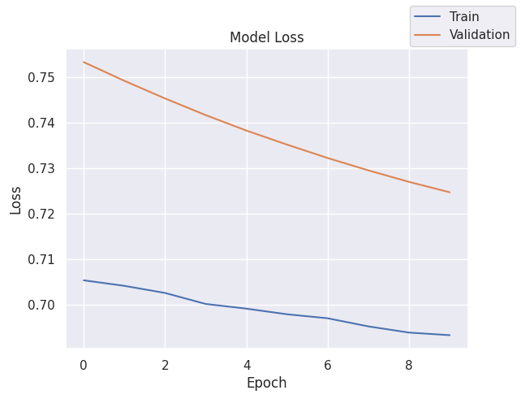

```python
plot(history_6, 'loss')
```

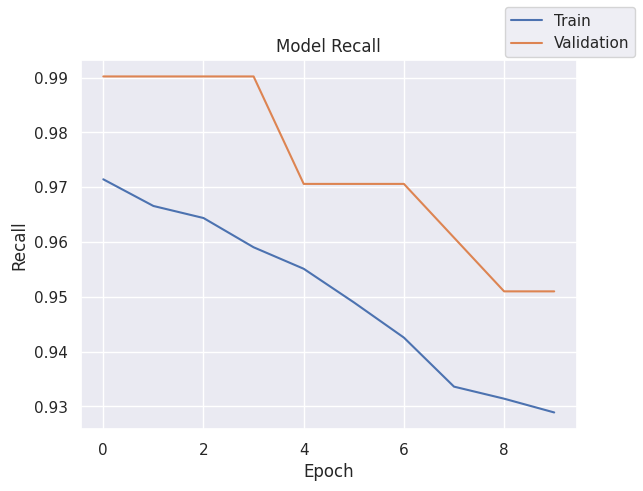

```python
plot(history_6, 'recall')
```

```python
#Predicting the results using best as a threshold
y_train_pred_asd = model_6.predict(X_train_smote)
y_train_pred_asd = (y_train_pred_asd > 0.5)
y_train_pred_asd
```

```
array([[ True],
       [ True],
       [ True],
       ...,
       [ True],
       [ True],
       [ True]])
```

```python
#Predicting the results using best as a threshold
y_val_pred_asd = model_6.predict(X_val)
y_val_pred_asd = (y_val_pred_asd > 0.5)
np.set_printoptions(threshold=10) # limit the threshold of the output
y_val_pred_asd
```

```
array([[ True],
       [ True],
       [ True],
       ...,
       [ True],
       [ True],
       [False]])
```

```python
# classification report
cr_asd_train = classification_report(y_train_smote, y_train_pred_asd)
print(cr_asd_train)
```

```
              precision    recall  f1-score   support

           0       0.61      0.12      0.20      6370
           1       0.51      0.92      0.66      6370

    accuracy                           0.52     12740
   macro avg       0.56      0.52      0.43     12740
weighted avg       0.56      0.52      0.43     12740
```

```python
# classification report
cr_asd_val = classification_report(y_val, y_val_pred_asd)
print(cr_asd_val)
```

```
              precision    recall  f1-score   support

           0       0.92      0.14      0.24       398
           1       0.22      0.95      0.36       102

    accuracy                           0.30       500
   macro avg       0.57      0.54      0.30       500
weighted avg       0.77      0.30      0.26       500
```

```
None
```

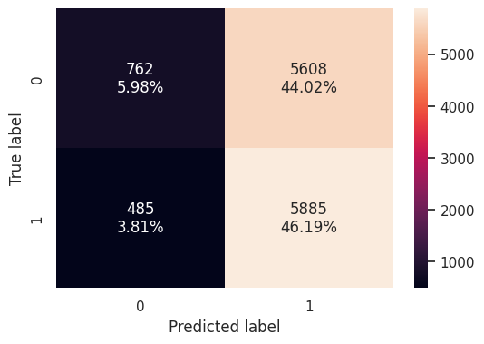

```python
cm_asd_train = make_confusion_matrix(y_train_smote, y_train_pred_asd)
print(cm_asd_train)
```

```
None
```

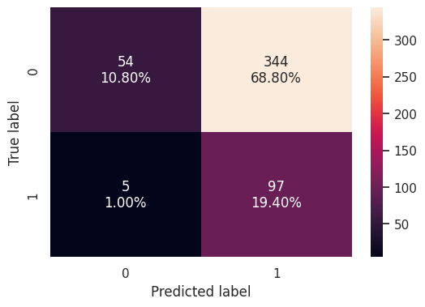

```python
cm_asd_val = make_confusion_matrix(y_val, y_val_pred_asd)
print(cm_asd_val)
```

```python
model_name = "NN with SMOTE, ADAM & Dropout"

train_metric_df.loc[model_name] = recall_score(y_train_smote, y_train_pred_asd)
valid_metric_df.loc[model_name] = recall_score(y_val, y_val_pred_asd)
```

# Model Performance Comparison & Model Selection

```python
print("Training performance comparison")
train_metric_df
```

```
Training performance comparison
```

|  | recall |
| --- | --- |
| NN with SGD | 0.827607 |
| NN with Adam | 0.888344 |
| NN with Adam & Dropout | 0.875460 |
| NN with SMOTE & SGD | 0.959812 |
| NN with SMOTE & ADAM | 0.949765 |
| NN with SMOTE, ADAM & Dropout | 0.923862 |

```python
print("Validation set performance comparison")
valid_metric_df
```

```
Validation set performance comparison
```

|  | recall |
| --- | --- |
| NN with SGD | 0.843137 |
| NN with Adam | 0.901961 |
| NN with Adam & Dropout | 0.911765 |
| NN with SMOTE & SGD | 0.950980 |
| NN with SMOTE & ADAM | 0.931373 |
| NN with SMOTE, ADAM & Dropout | 0.950980 |

```python
train_metric_df - valid_metric_df
```

|  | recall |
| --- | --- |
| NN with SGD | -0.015530 |
| NN with Adam | -0.013617 |
| NN with Adam & Dropout | -0.036305 |
| NN with SMOTE & SGD | 0.008831 |
| NN with SMOTE & ADAM | 0.018392 |
| NN with SMOTE, ADAM & Dropout | -0.027119 |

When selecting the best model, I'd like to consider a variety of aspects holistically rather than solely basing my decision on final recall score, as follows:

- Although SMOTE & SGD seem to have performed better across both training and validation set, the model seems to have been one of the worse performing when predicting label 0. Additionally, SGD seemed to have performed worse without SMOTE compared to Adam.
- More importantly, we seem to be observing a higher learning rate in SMOTE & Adam paired with a better performing model when predicting instances of class 0.
- Although accurately predicting label 1 is at the center of our priority, it's important to evaluate the model in a holistic manner and ensuring that other parameters are performing in line with our business requirements.
- We're therefore selecting SMOTE & Adam as our best performing model.

```python
y_test_pred = model_5.predict(X_test)
y_test_pred = (y_test_pred > 0.5)
print(y_test_pred)
```

```
[[ True]
 [ True]
 [ True]
 ...
 [ True]
 [ True]
 [ True]]
```

```python
#lets print classification report
cr=classification_report(y_test,y_test_pred)
print(cr)
```

[output not shown]

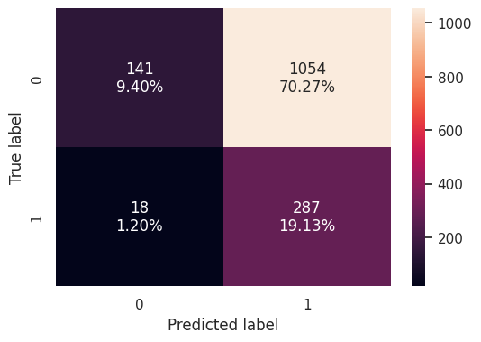

```python
#Calculating the confusion matrix
make_confusion_matrix(y_test,y_test_pred)
```

# Business Insights & Recommendation

**Model Observations**

- We began with a baseline model with 1 hidden layer, using SGD optimizer and 10 epochs.
- We've explored the effects of increasing epochs and observed that our model seems to be performing better with a lower number of epochs - ultimately keeping it at 10.
- When epxloring SGD vs Adam we found Adam to be performing better without the introduction of SMOTE and almost to par with SGD with the introduction of SMOTE.
- Due to a significant class imbalance observed in our dataset, we found that the introduction of SMOTE was absolutely essential to improve the performance of our model.
- The introduction of dropouts seem to have a relatively positive effect in our model performance, but despite much experimentation we did not observe the improvemenet we were expecting. Further experimentation will be required to introduce additional parameters in this respect.
- The class imbalance was a significant problem. We were able to imrpove our model to a relatively high recall rate against class 1 but were unable to balance the same performance for class 0. Each time we'd see an improvement in class 0 performance, we'd observe a signficant impact in performance of class 1. Given our business requirements we've opted for an approach that would ensure high recall on class 1.
- The user of weights could also be an effective approach to improve class imbalance.

**Insights & Business Recommendations**

- Our neural networks model was able to successfully predict churn in customers who were in fact going to churn. There are some key considerations that should guide further attempts to improve this model - such as the fact that the model was not strong in predicting false positives and precision and accuracy still required further improvement.
- Our analysis indicated that the following factors may be important to consider when looking at the impact to our target variable:

Demographically: `age` had a somewhat impact where younger customers were identified to be more likely to chur; `female` customers seem to demonstrate higher incidences of churn; `german` customers were more likely to churn (although further data to improve representation of this segment of the population is advised)

User Behavior: `New customers`, customers with a lower `balance` and customer who hadn't been `active` in a while seem to display higher probabilities of churn - which can be explained by the perceived lack of value observed in the product. Now, a surprising factor, is that we also observed higher rates of churn amongst customers with `3 or more products`, indicating a specific problem in customer who seem to have had more experience with and to be more loyal to the brand.

**Key takeaways**

- It would be valuable for the business to look into aspects customer nurturing, re-engagement and retention strategies.
- Additionally, further exploring some of the causes that could be behind churn in what seems to be a segment of loyal customers could bring great value to the business.
- More importantly, it would be advisable to gather more balanced data to help us observe and replicate insights for specific segments within our customer base.